# Template

### Data Trends

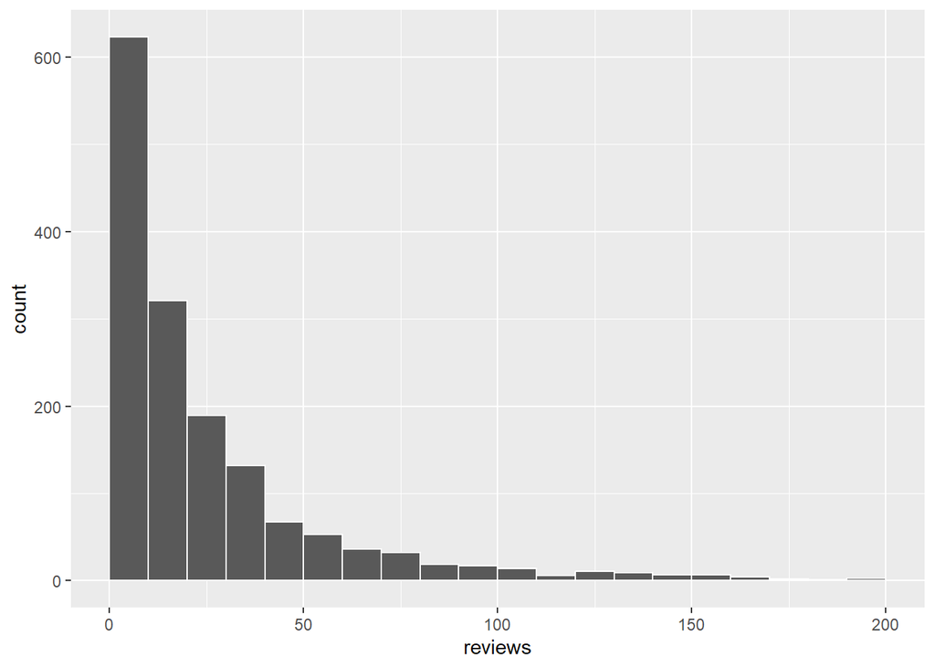

```r
ggplot(airbnb, aes(x = reviews)) +
  geom_histogram(color = "white", breaks = seq(0, 200, by = 10))
```

First note that the distribution of our response variable is lower bounded at 0, and peaks in the first bin with a long right skew.

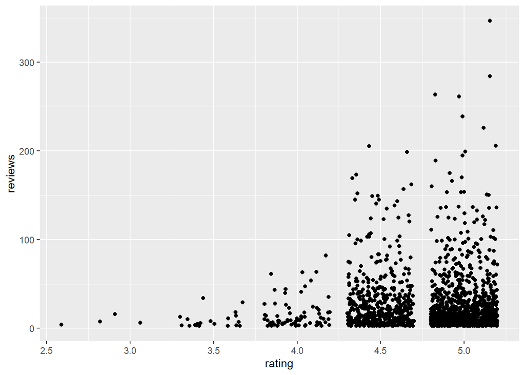

```r
ggplot(airbnb, aes(y = reviews, x = rating)) +
  geom_jitter()
```

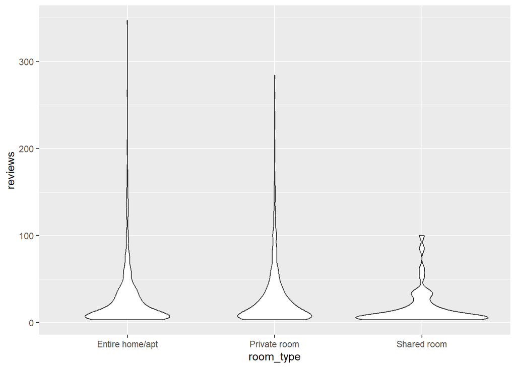

```r
ggplot(airbnb, aes(y = reviews, x = room_type)) +
  geom_violin()
```

Further, the volume of reviews tends to increase with ratings and privacy levels.

We can further break down these dynamics within each neighborhood. We show three here. In general, notice that Albany Park listings tend to have fewer reviews, no matter their rating or room type.

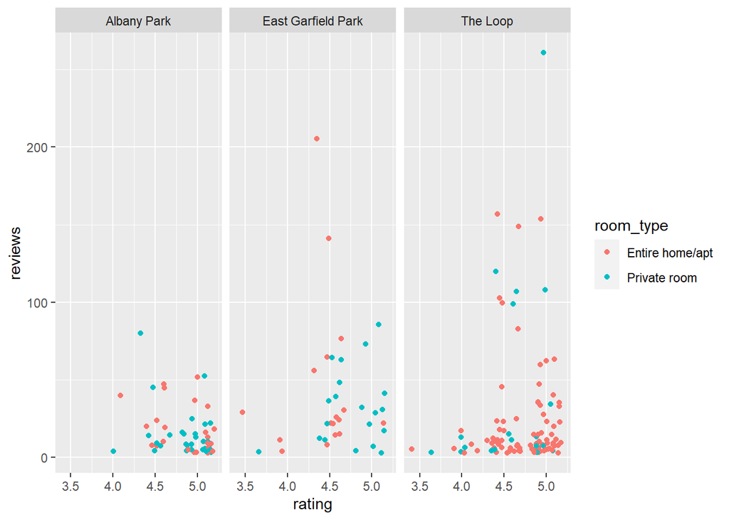

```r
airbnb %>%
  filter(neighborhood %in%
           c("Albany Park", "East Garfield Park", "The Loop")) %>%
  ggplot(aes(y = reviews, x = rating, color = room_type)) +
    geom_jitter() +
    facet_wrap(~ neighborhood)
```

### Define Model

In building a regression model for the number of reviews, the first step is to consider reasonable probability models for data $Y_{ij}$. Since the $Y_{ij}$ values are *non-negative skewed counts*, a **Poisson** model is a good starting point. Let $\lambda_{ij}$ denote the expected number of reviews received by listing $i$ in neighborhood $j$:

$$Y_{ij}|\lambda_{ij} \sim
Pois(\lambda_{ij})$$

### Hierarchical Poisson Regression Model

$$Y_{ij}{|\beta_{0j},\beta_1,\beta_2,\beta_3 \sim
Pois(\lambda_{ij})} \text{ with } log(\lambda_{ij}) = \beta_{0j} +
\beta_1X_{ij1} + \beta_2X_{ij2} + \beta_3X_{ij3}$$

$$\beta_{0j}|\beta_0,\sigma_0 \sim
N(\beta_0, \sigma_0^2)$$

$$\beta_{0c} \sim N(3, 2.5^2)$$

$$\beta_1 \sim N(0, 7.37^2)$$

$$\beta_2 \sim N(0, 5.04^2)$$

$$\beta_3 \sim N(0, 14.19^2)$$

$$\sigma_0 \sim Exp(1)$$

Assumes neighborhoods might have unique intercepts $\beta_{0j}$, but share common regression parameters ($\beta_1,\beta_2,\beta_3$). In English: though some neighborhoods might have might have more popular AirBnB destinations that others, the relationship of reviews with ratings and room type is the same for each neighborhood. For instance, ratings aren’t more influential to reviews in one neighborhood than in another.

```r
airbnb_model_1 <- stan_glmer(
  reviews ~ rating + room_type + (1 | neighborhood),
  data=airbnb, family=poisson,
  prior_intercept = normal(3, 2.5, autoscale=TRUE),
  prior = normal(0, 2.5, autoscale=TRUE),
  prior_covariance = decov(reg=1,conc=1,shape=1,scale=1),
  chains=4, iter= 5000*2, seed=84735
)
```

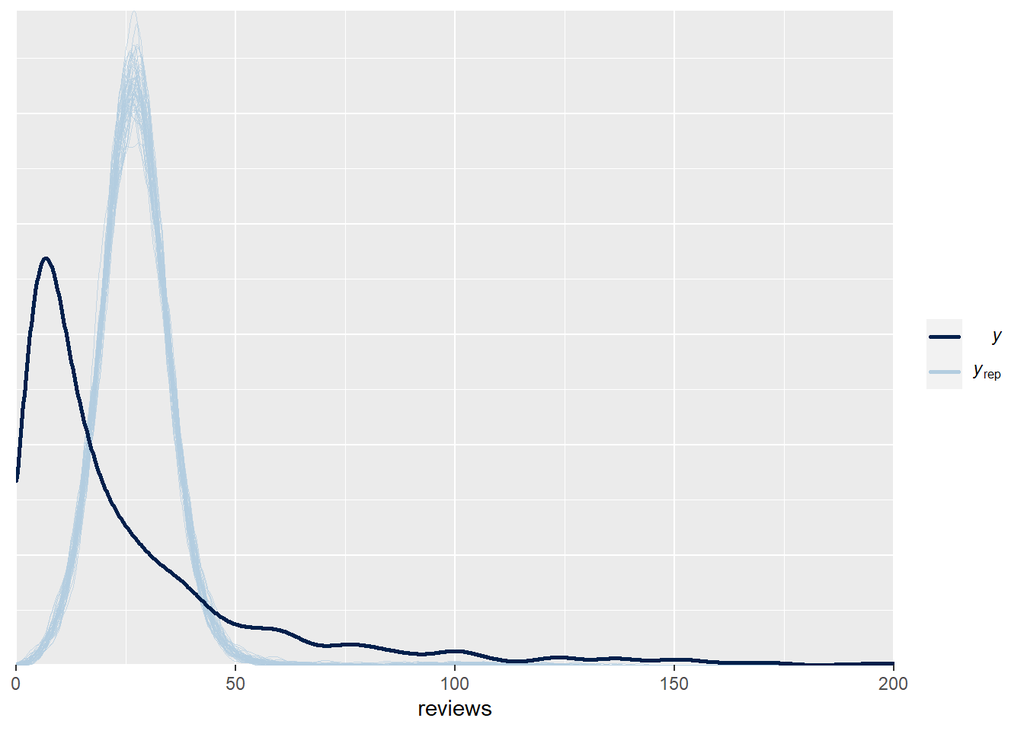

```r
pp_check(airbnb_model_1)+
  xlim(0,200) +
  xlab("reviews")
```

Our posterior check indicates that our hierarchical Poisson regression model significantly underestimates the variability in reviews from listing to listing, while overestimating the typical number of reviews. Recall that an underlying Poisson regression assumption is that, at any set of predictor values, the *average* number of reviews is equal to the variance in reviews:

$$E(Y_{ij}) = Var(Y_{ij}) =
\lambda_{ij}$$

Our posterior check calls this assumption into question. To address the apparent **overdispersion** in the $Y_{ij}$ values, we swap out the Poisson model for the more flexible Negative Binomial model

### Hierarchical Negative Binomial Regression Model

Picking up the additional reciprocal dispersion parameter $r > 0$:

$$Y_{ij}{|\beta_{0j},\beta_1,\beta_2,\beta_3 \sim
NegBin(\mu_{ij},r)} \text{ with } log(\mu_{ij}) = \beta_{0j} +
\beta_1X_{ij1} + \beta_2X_{ij2} + \beta_3X_{ij3}$$

$$\beta_{0j}|\beta_0,\sigma_0 \sim
N(\beta_0, \sigma_0^2)$$

$$\beta_{0c} \sim N(3, 2.5^2)$$

$$\beta_1 \sim N(0, 7.37^2)$$

$$\beta_2 \sim N(0, 5.04^2)$$

$$\beta_3 \sim N(0, 14.19^2)$$
$$r \sim Exp(1)$$

$$\sigma_0 \sim Exp(1)$$

Equivalently, we can express the random intercepts as tweaks to the global intercept:

$$log(\mu_{ij}) = (\beta_0 + b_{0j}) +
\beta_1X_{ij1} + \beta_2X_{ij2} + \beta_3X_{ij3}$$

where $\b_{0j}|\sigma_0 \sim N(0,\sigma_0^2)$. To simulate the posterior we can swap out `family = poisson` for `family = neg_binomial_2`:

```r
airbnb_model_2 <- stan_glmer(
  reviews ~ rating + room_type + (1 | neighborhood),
  data = airbnb, family = neg_binomial_2,
  prior_intercept = normal(3, 2.5, TRUE),
  prior = normal(0, 2.5, TRUE),
  prior_aux = exponential(1, TRUE),
  prior_covariance = decov(1,1,1,1),
  chains = 4, iter = 5000*2, seed = 84735
)
```

Though not perfect, the negative binomial model does a *much* better job capturing behavior in reviews from listing to listing:

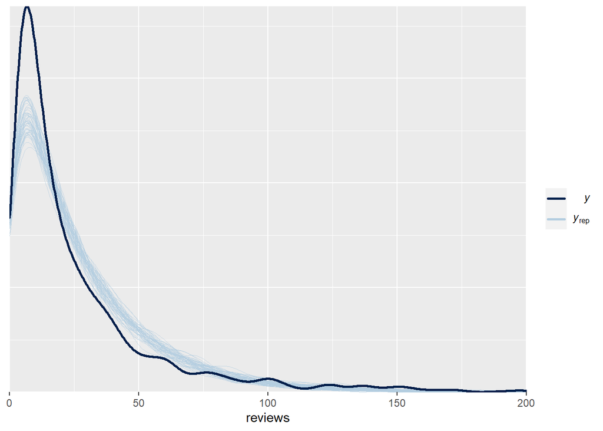

```r
pp_check(airbnb_model_2) +
  xlim(0, 200) +
  xlab("reviews")
```

## Posterior Analysis

First lets explore the global relationship of reviews with ratings and room type, $log(\lambda_{ij}) = \beta_0 + \beta_1X_{ij1} + \beta_2X_{ij2} + \beta_3X_{ij3}$, or:

$$\lambda_{ij} = exp(\beta_0 +
\beta_1X_{ij1} + \beta_2X_{ij2} + \beta_3X_{ij3})$$

Below are posterior summaries of our global parameters ($\beta_0, \beta_1, \beta_2, \beta_3$).

```r
tidy(airbnb_model_2, effects="fixed", conf.int=TRUE, conf.level=0.8)
```

```
## # A tibble: 4 × 5
##   term                  estimate std.error conf.low conf.high
##   <chr>                    <dbl>     <dbl>    <dbl>     <dbl>
## 1 (Intercept)             2.00      0.399   1.49        2.51
## 2 rating                  0.264     0.0838  0.157       0.371
## 3 room_typePrivate room   0.0683    0.0524  0.00164     0.135
## 4 room_typeShared room   -0.470     0.150  -0.659      -0.273
```

From the summaries, the posterior model of $\beta_1$ reflects a significant and substantive positive association between reviews and rating. When controlling, there’s an 80% chance that the volume of reviews increases somewhere between 1.17 and 1.45 times (17% - 45%), or every extra point in rating: ($e^{0.154}, e^{0.371}$) = (1.17, 1.45).

In Contrast, the posterior model of $\beta_3$ illustrates that shared rooms are negatively associated with reviews. When controlling for ratings, there’s an 80% chance that the volume of reviews for shared room listings is somewhere between 52 and 76 percent as high as for listings that are entirely private: ($e^{0.659}, e^{-0.275}$) = (0.52, 0.76)

Lets also look at some **neighborhood-specific** AirBnB models. We’ll focus on the three same neighborhoods.

```r
tidy(airbnb_model_2, effects = "ran_vals",
     conf.int = TRUE, conf.level = 0.80) %>%
  select(level, estimate, conf.low, conf.high) %>%
  filter(level %in% c("Albany_Park", "East_Garfield_Park", "The_Loop"))
```

```
## # A tibble: 3 × 4
##   level              estimate conf.low conf.high
##   <chr>                 <dbl>    <dbl>     <dbl>
## 1 Albany_Park        -0.232    -0.427    -0.0520
## 2 East_Garfield_Park  0.199     0.0342    0.395
## 3 The_Loop            0.00965  -0.102     0.128
```

Note that:

1. AirBnB listings in Albany Park have atypically few reviews
2. East Garfield Park has atypically larger number of reviews
3. Those in the loop do not significantly differ from average

Below we simulate 3 listings each with 5 star ratings and whole unit private in different locations:

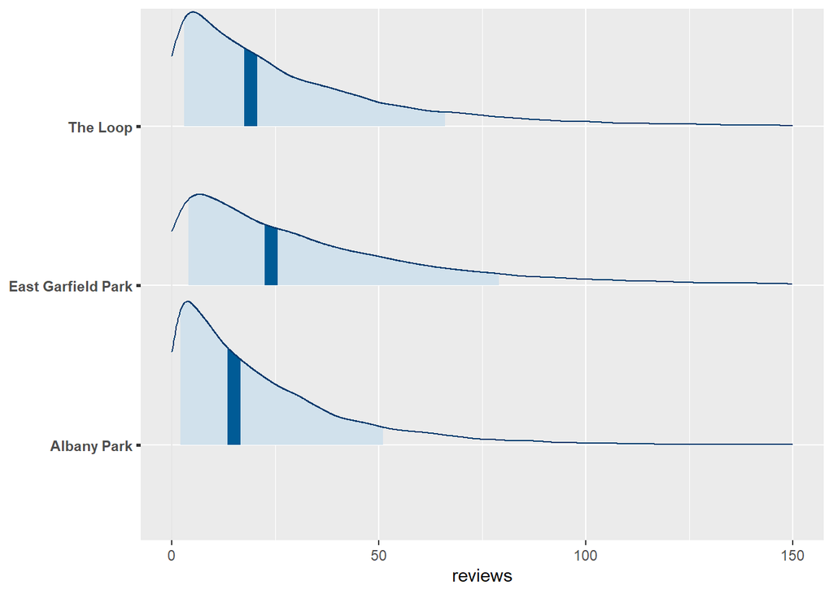

```r
# Posterior predictions of reviews
set.seed(84735)
predicted_reviews <- posterior_predict(
  airbnb_model_2,
  newdata = data.frame(
    rating = rep(5, 3),
    room_type = rep("Entire home/apt", 3),
    neighborhood = c("Albany Park", "East Garfield Park", "The Loop")))
mcmc_areas(predicted_reviews, prob = 0.8) +
  ggplot2::scale_y_discrete(
    labels = c("Albany Park", "East Garfield Park", "The Loop")) +
  xlim(0, 150) +
  xlab("reviews")
```

```r
set.seed(84735)
prediction_summary(airbnb_model_2, data = airbnb)
```

```
##        mae mae_scaled within_50 within_95
## 1 17.65255  0.6748079 0.5169763 0.9577194
```